# Homework 10

*Andrew Gillock apg2255*

**This homework is due on April 25, 2022 at 11:00am. Please submit as a pdf file on Canvas.**

**Problem 1: (3 pts)** For Problem 1, we will be using `happiness` taken from the World Happiness Report. You can read more about the dataset here: https://www.kaggle.com/datasets/unsdsn/world-happiness.

```r
# data preparation
happiness <- read_csv("https://wilkelab.org/SDS375/datasets/happiness.csv")
head(happiness)
```

| country | happiness_score | GDP | family_score | health_life_expectancy_score | freedom_score | government_trust_score | generosity_score | dystopia_score |
| --- | --- | --- | --- | --- | --- | --- | --- | --- |
| Switzerland | 7.587 | 1.39651 | 1.34951 | 0.94143 | 0.66557 | 0.41978 | 0.29678 | 2.51738 |
| Iceland | 7.561 | 1.30232 | 1.40223 | 0.94784 | 0.62877 | 0.14145 | 0.43630 | 2.70201 |
| Denmark | 7.527 | 1.32548 | 1.36058 | 0.87464 | 0.64938 | 0.48357 | 0.34139 | 2.49204 |
| Canada | 7.427 | 1.32629 | 1.32261 | 0.90563 | 0.63297 | 0.32957 | 0.45811 | 2.45176 |
| Finland | 7.406 | 1.29025 | 1.31826 | 0.88911 | 0.64169 | 0.41372 | 0.23351 | 2.61955 |
| Netherlands | 7.378 | 1.32944 | 1.28017 | 0.89284 | 0.61576 | 0.31814 | 0.47610 | 2.46570 |

1. Perform hierarchical clustering of the countries and calculate the distance matrix. You do not need to display the distance matrix.
2. Display clustering results in a dendrogram.

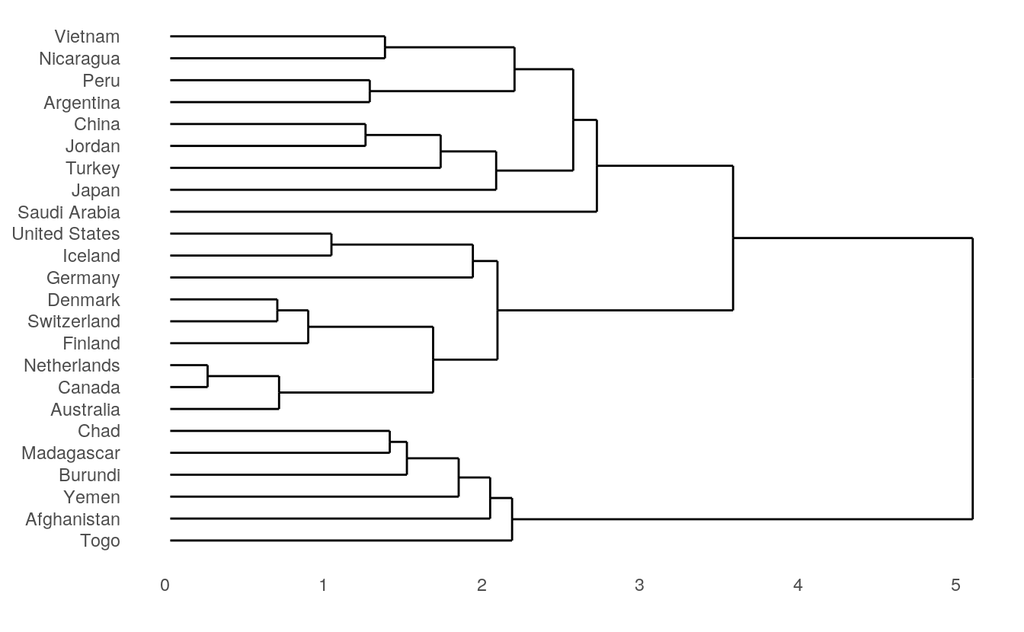

```r
dist_out <- happiness %>%
  column_to_rownames(var = "country") %>%
  scale() %>%
  dist(method = "euclidean")

hc_out <- hclust(
  dist_out, method = "average" #UPGMA
)

ggdendrogram(hc_out, rotate = TRUE)
```

**Problem 2: (3 pts)** Use the clustering results you found in Problem 1 for Problem 2.

1. Assign clusters by cutting the dendrogram.
2. Plot a scatter plot for two numeric variables of your choice from `happy_data` and add cluster info into scatterplot.
3. Interpret the plot.

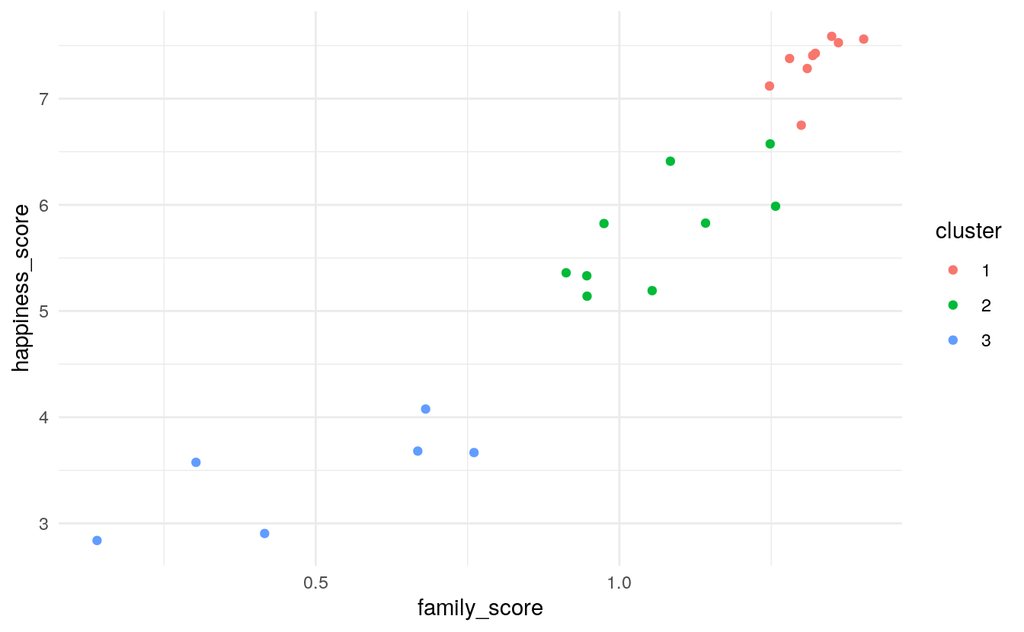

```r
cluster <- cutree(hc_out, k = 3)

happiness %>% left_join(
  tibble(
    country = names(cluster),
    cluster = factor(cluster)
  )
) %>% ggplot(aes(family_score, happiness_score)) +
  geom_point(aes(color = cluster)) +
  theme_minimal()
```

*The euclidean distance between each country was determined and clusters were assigned for countries that were most similar. Examining the plot, we can see that we have a linear relationship between a country’s happiness score and family score, where each data point is representing a different country in the dataset.*

**Problem 3: (4 pts)** For Problem 3, we will work with the dataset `texas_income`.

1. Bin the `median_income` column into 3 bins (20K-40K, 40K-60K, 60K-90K). Hint: use `case_when()`.
2. Make a choropleth map of Texas counties colored by median income bin (3 total colors).
3. Use an appropriate color scale and use a theme that shows longitude and latitude (nearly any theme other than `theme_void()` will work).

```r
# data preparation
texas_income <- readRDS(url("https://wilkelab.org/SDS375/datasets/Texas_income.rds"))
head(texas_income)
```

|  | FIPS | county | median_income | moe | geometry |
| --- | --- | --- | --- | --- | --- |
| 1 | 48001 | Anderson | 41327 | 1842 |  |
| 2 | 48003 | Andrews | 70423 | 6038 |  |
| 3 | 48005 | Angelina | 44223 | 1611 |  |
| 4 | 48007 | Aransas | 41690 | 3678 |  |
| 5 | 48009 | Archer | 60275 | 5182 |  |
| 6 | 48011 | Armstrong | 59737 | 4968 |  |

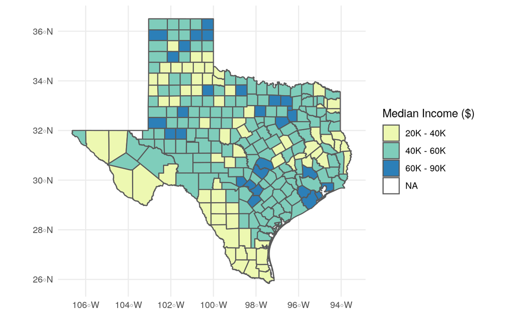

```r
texas_income  %>%  #should i remove this
  mutate(
  bin = case_when(
    median_income >= 20000 & median_income < 40000 ~ "20K - 40K",
    median_income >= 40000 & median_income < 60000 ~ "40K - 60K",
    median_income >= 60000 & median_income < 90000 ~ "60K - 90K"
  )
) %>% ggplot(aes(fill = bin)) + geom_sf() +
  scale_fill_brewer(
  name = "Median Income ($)",
  palette = "YlGnBu"
) + theme_minimal()
```